# COMPSCIX 415.2 Homework 9/Final

Chi Nguyen

3/26/2019

My Github repository for my assignments can be found at this URL: https://github.com/chimandy/compscix-415-2-assignments.git

```r
library(mdsr)
library(tidyverse)
```

```r
library(broom)
library(ggplot2)
```

Sampling distributions and standard error Functions and loops AB testing Linear regression

# Exercises (Total Points - 20)

## Exercise 1 - Sampling Distributions, Functions and For Loops (10 points)

The exponential distribution has a rate parameter that controls how quickly the distribution decays and defines what the mean and standard deviation will be. In our case the rate = 1/10000, the mean = 10000 and the standard deviation = 10000. You can sample from this exponential distribution in R using this code:

```r
# sample size
samp_size <- 100
# set the rate parameter
samp_rate <- 1/10000

# take sample
rexp(n = samp_size, rate = samp_rate)
```

```
##   [1]  2671.8861  1311.5776   562.7652  3781.3150 26471.0548  2582.5255
##   [7]  4659.1045  7290.3053  4333.7571  4021.6771  3172.8866  2309.3039
##  [13]  3603.9327  3179.7185 11984.0746 15590.0949  3001.8779 14512.2612
##  [19]  1929.8376  4002.7899  8343.5257 20168.6643   120.0297  4912.3928
##  [25]  8436.2156 24649.8286  6632.1795  1298.3645 15437.6180  2417.9316
##  [31] 30271.3135  6501.4680 22825.7504 14162.1775  2484.1079  9447.8021
##  [37]  8286.5816  3129.1151  6459.6258 28421.1665  2002.1436  4254.4581
##  [43] 13275.2087 18575.5810  1808.1161 15561.5302 11080.4957  2692.3821
##  [49] 22281.2523 12234.4017  5024.1120 27901.8871  2658.4329 24080.5357
##  [55] 20359.3899  6634.1951 40122.6619 11644.7616  7449.1312  8007.1235
##  [61]  6912.9633  2710.5766 23381.7577 10565.9923 13743.0381 19676.9098
##  [67]  8112.6702 12476.2751  3215.2209  9961.9624 11500.7551   177.6401
##  [73]  3596.8822  4419.7290  4520.3722 10314.2168 27174.2509  4721.2820
##  [79]  3036.2672  9180.6140 12438.7828  5800.8597  8589.0768  4523.7424
##  [85]  2089.4792 23550.0077  6534.4074 23697.1038 11810.1283  1402.6258
##  [91]  5081.3499 18211.3392  6503.0736  3946.3290  4750.2246 15454.7553
##  [97]   746.4130 11697.3172 19349.6035  1492.0012
```

### *Step 1*

Write an R function that does the following:

-Takes a sample of size samp_size from this exponential distribution (samp_size is an input parameter for the function) -Calculates the mean of that sample -Calculates the standard deviation of that sample -Returns the calculated mean and standard deviation as a list Helper code

```r
samp_fun <- function(samp_size, samp_rate) {
  df<-rexp(n = samp_size, rate = samp_rate)
  samp_avg<-mean(df)
  samp_std_dev<-sd(df)
  stats <- list(samp_avg = samp_avg, samp_std_dev = samp_std_dev)
  return(stats)
}
samp_fun(samp_size,samp_rate)
```

```
## $samp_avg
## [1] 9897.299
##
## $samp_std_dev
## [1] 9996.038
```

```r
samp_result<-samp_fun(samp_size,samp_rate)
```

### *Step 2*

Then write a loop that does this:

Runs the above function 1000 times, with samp_size = 50 and samp_rate = 1/10000 Saves all of the sample means in a vector called sample_means, and all of the sample standard deviations in a vector called sample_sds

```r
n <-1000#how many samples
sample_means<-rep(NA,n)
sample_sds<-rep(NA,n)
for(i in 1:n){
  my_result<-samp_fun(50,1/10000)
  sample_means[i]<-my_result$samp_avg
  sample_sds[i]<-my_result$samp_std_dev
}
all_results<-tibble(sample_means,sample_sds)
all_results
```

```
## # A tibble: 1,000 x 2
##    sample_means sample_sds
##           <dbl>      <dbl>
##  1        9459.      7515.
##  2        7457.      5192.
##  3       12971.     15140.
##  4        7925.      7919.
##  5       11286.     15646.
##  6        9659.      8626.
##  7       11467.     10355.
##  8        9077.      9794.
##  9        7972.      6043.
## 10        9848.      9114.
## # … with 990 more rows
```

### *Step 3*

-Then plot your sample means as a histogram -output the standard deviation of your sample means -calculate the theoretical standard error (σ=10000, n = sample size) -calculate the mean of the sample standard deviations and use this to calculate the empirical standard error

*Plot sample_means*

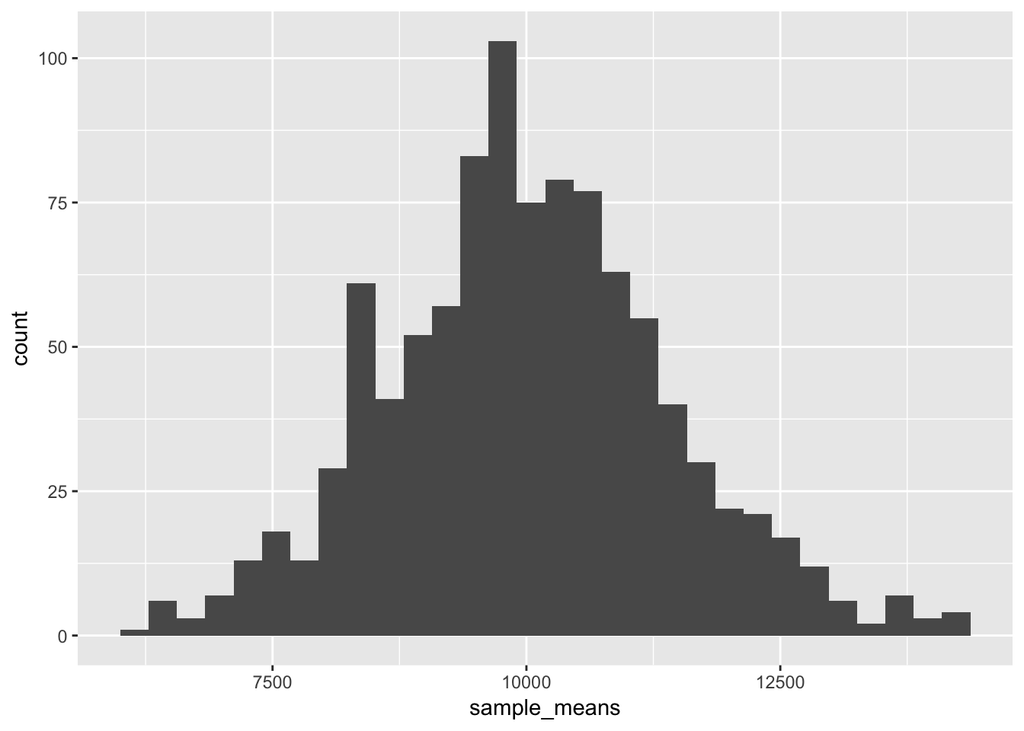

```r
sample_means_df<-data.frame(sample_means)
sample_means_df %>% ggplot()+
  geom_histogram(aes(x=sample_means))
```

*Output standard deviation for sample_means*

```r
sample_means_std<-sd(sample_means_df$sample_means)
sample_means_std
```

```
## [1] 1396.695
```

*Calculate the theoretical standard error (σ=10000, n = sample size)*

```r
theoratical_sd<-10000/sqrt(50)
theoratical_sd
```

```
## [1] 1414.214
```

*Calculate the mean of the sample standard deviations and use this to calculate the empirical standard error*

```r
sample_sds_df<-data.frame(sample_sds)
mean_sample_sds<-mean(sample_sds_df$sample_sds)
emprical_sd<-mean_sample_sds/sqrt(50)
emprical_sd
```

```
## [1] 1389.134
```

### *Step 4*

Repeat STEP 2 and STEP 3 using a sample size of 5000.

```r
n <-1000#how many samples
sample_means<-rep(NA,n)
sample_sds<-rep(NA,n)
for(i in 1:n){
  my_result<-samp_fun(5000,1/10000)
  sample_means[i]<-my_result$samp_avg
  sample_sds[i]<-my_result$samp_std_dev
}
all_results<-tibble(sample_means,sample_sds)
all_results
```

```
## # A tibble: 1,000 x 2
##    sample_means sample_sds
##           <dbl>      <dbl>
##  1        9844.      9649.
##  2        9933.      9986.
##  3       10097.     10201.
##  4       10128.     10287.
##  5       10075.     10093.
##  6       10097.     10138.
##  7       10116.     10165.
##  8       10057.     10156.
##  9       10026.     10198.
## 10       10383.     10505.
## # … with 990 more rows
```

```r
sample_means_df<-data.frame(sample_means)
sample_means_df
```

[output not shown]

[output cut: 986 more lines]

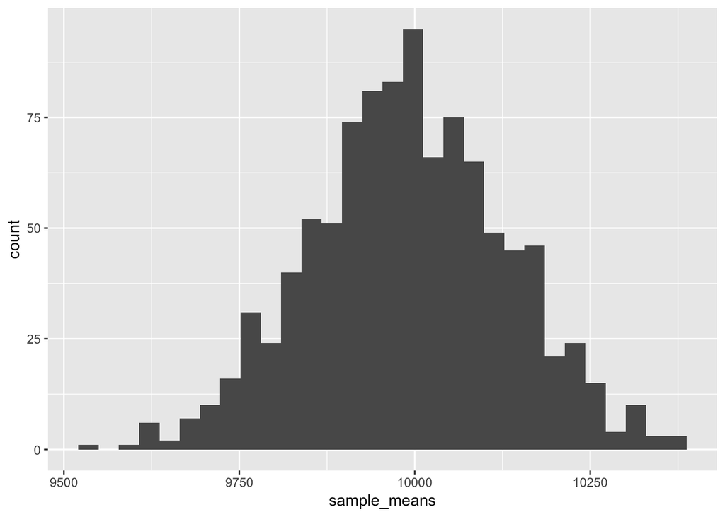

```r
sample_means_df %>% ggplot()+
  geom_histogram(aes(x=sample_means))
```

```r
sample_means_std<-sd(sample_means_df$sample_means)
sample_means_std
```

```
## [1] 139.5481
```

```r
theoratical_sd<-10000/sqrt(5000)
theoratical_sd
```

```
## [1] 141.4214
```

```r
sample_sds_df<-data.frame(sample_sds)
mean_sample_sds<-mean(sample_sds_df$sample_sds)
emprical_sd<-mean_sample_sds/sqrt(5000)
emprical_sd
```

```
## [1] 141.2163
```

## Exercise 2 - Linear Regression (5 points)

For this exercise we will return to the House Prices prediction dataset that we used for HW 7. You should have already downloaded the train.csv dataset before, but if you didn’t you can download it from Canvas in this week’s module.

Load the train.csv dataset into R and fit a regression model with:

y = SalePrice Features: LotArea, OverallQual, and ExterQual Answer these questions:

-Use the broom package to output the coefficients and the R-squared -Interpret the coefficient on LotArea -Interpret the coefficient on ExterQualGd -Compare this model to the model we fit in HW 7 with GrLivArea, OverallQual, Neighborhood. Which is the better fitting model?

*Use the broom package to output the coefficients and the R-squared*

```r
file_path<-'train.csv'
train_data<- read_csv(file='train.csv')
train_mult_lm_2 <- lm(formula=SalePrice ~ LotArea + OverallQual + ExterQual, data = train_data)
tidy(train_mult_lm_2)
```

```
## # A tibble: 6 x 5
##   term         estimate std.error statistic   p.value
##   <chr>           <dbl>     <dbl>     <dbl>     <dbl>
## 1 (Intercept)  40764.   12358.         3.30 9.95e-  4
## 2 LotArea          1.45     0.116     12.5  3.72e- 34
## 3 OverallQual  34466.    1216.        28.3  4.77e-141
## 4 ExterQualFa -95352.   14592.        -6.53 8.80e- 11
## 5 ExterQualGd -71529.    6737.       -10.6  2.05e- 25
## 6 ExterQualTA -97527.    7541.       -12.9  2.72e- 36
```

```r
glance(train_mult_lm_2)
```

```
## # A tibble: 1 x 11
##   r.squared adj.r.squared  sigma statistic p.value    df  logLik    AIC
##       <dbl>         <dbl>  <dbl>     <dbl>   <dbl> <int>   <dbl>  <dbl>
## 1     0.695         0.694 43948.      663.       0     6 -17677. 35368.
## # … with 3 more variables: BIC <dbl>, deviance <dbl>, df.residual <int>
```

```r
summary(train_mult_lm_2)
```

```
##
## Call:
## lm(formula = SalePrice ~ LotArea + OverallQual + ExterQual, data = train_data)
##
## Residuals:
##     Min      1Q  Median      3Q     Max
## -318248  -24842   -1716   18613  408405
##
## Coefficients:
##               Estimate Std. Error t value Pr(>|t|)
## (Intercept)  4.076e+04  1.236e+04   3.299 0.000995 ***
## LotArea      1.453e+00  1.162e-01  12.506  < 2e-16 ***
## OverallQual  3.447e+04  1.216e+03  28.341  < 2e-16 ***
## ExterQualFa -9.535e+04  1.459e+04  -6.535  8.8e-11 ***
## ExterQualGd -7.153e+04  6.737e+03 -10.617  < 2e-16 ***
## ExterQualTA -9.753e+04  7.541e+03 -12.932  < 2e-16 ***
## ---
## Signif. codes:  0 '***' 0.001 '**' 0.01 '*' 0.05 '.' 0.1 ' ' 1
##
## Residual standard error: 43950 on 1454 degrees of freedom
## Multiple R-squared:  0.695,  Adjusted R-squared:  0.694
## F-statistic: 662.7 on 5 and 1454 DF,  p-value: < 2.2e-16
```

*Interpret the coefficient on LotArea* LotArea: Lot size in square feet

For every extra square foot of lot area, the sale price increases, on average, $1.45 , with all other features being held constant. For this model, for every one unit increae in the overall quality of the lot area, the mean increase in the sale price is $34466.

*Interpret the coefficient on ExterQualGd* ExterQual: Evaluates the quality of the material on the exterior

```
   Ex   Excellent
   Gd   Good
   TA   Average/Typical
   Fa   Fair
   Po   Poor
```

the negative coeeficient on ExterQualGd states that if the quality of the material on exterior is good graded but not excellent, the price difference will be -$71,529 compared to the excellent graded.

*Compare this model to the model we fit in HW 7 with GrLivArea, OverallQual, Neighborhood. Which is the better fitting model?*

The previous R-squared from HW7 is (.78), which is larger than R-Squared from this model (0.695). As a result, the previous model we fit in WH 7 with GrLivArea, OverallQual, Neighborhood is better fitting model.

## Exercise 3 - AB Testing (5 points)* Download the ab_test_data.csv file from Canvas. This file contains two columns: version and conversion. Each row is a visitor to a webpage. The version column tells us which version of the webpage the visitor saw, and the conversion column is a binary value and equals 1 if the visitor converted (0 otherwise).

```r
df <- read.table("ab_test_data.csv", header=TRUE,
   sep=",")
glimpse(df)
```

```
## Observations: 4,000
## Variables: 2
## $ version    <fct> A, A, A, A, A, A, A, A, A, A, A, A, A, A, A, A, A, A,…
## $ conversion <int> 0, 0, 0, 0, 0, 0, 0, 0, 0, 0, 0, 0, 0, 0, 0, 0, 0, 0,…
```

```r
df
```

[output not shown]

[output cut: 3986 more lines]

We want to perform an AB test on this data to see if the conversion rates are different for the two versions of the webpage.

Answer these questions:

#### a.What proportion of visitors converted for each version of the webpage?

*Proportion of vistors converted for version A*

```r
number_A<-df%>%filter(version=='A')%>%count()
number_A_converted<-df%>%filter(conversion==1)%>%filter(version=='A')%>%count()
proportion_A_converted<-number_A_converted/number_A
true_a<-proportion_A_converted
true_a<-true_a[[1]]
true_a
```

```
## [1] 0.0415
```

*Proportion of vistors converted for version B*

```r
number_B<-df%>%filter(version=='B')%>%count()
number_B_converted<-df%>%filter(conversion==1)%>%filter(version=='B')%>%count()
proportion_B_converted<-number_B_converted/number_A
true_b<-proportion_B_converted
true_b<-true_b[[1]]
true_b
```

```
## [1] 0.1
```

#### b.Perform the AB test in R. What is the p-value for the AB test (hypothesis test of proportions)?

```r
n_a =number_A[[1]]
n_b =number_B[[1]]
set.seed(10)
samp_a <-rbinom(n = 1, size = n_a, prob = true_a)
samp_b <-rbinom(n = 1, size = n_b, prob = true_b)
samp_a
```

```
## [1] 93
```

```r
samp_b
```

```
## [1] 200
```

```r
two_prop_test <- prop.test(c(samp_a, samp_b), c(n_a, n_b))
two_prop_test$p.value
```

```
## [1] 1.25388e-10
```

The p-value,which is smaller than 0.05, tells us that the conversion rates for Version A and B are significantly different than each other, so we’d conclude here that whatever changes were made to the webpage did have an effect.